# 2021 경제인문사회연구회 맞춤형

### 정규성과 등분산성을 만족하기 위해 반응변수를 변환

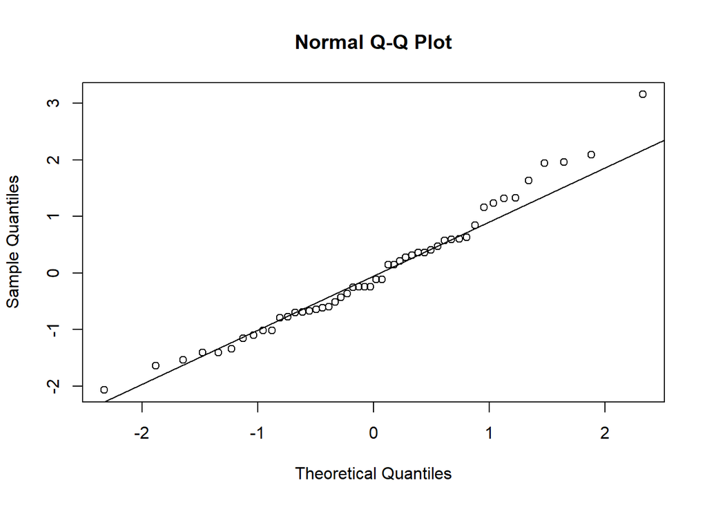

```r
out2 <- lm(sqrt(dist)~speed,data=cars)
qqnorm(out2$residuals)
qqline(out2$residuals) # Q-Q plot을 이용한 정규성 검정 (점이 선 위에 있을 수록 정규분포를 따름)
```

```r
shapiro.test(out2$residuals) # 정규성을 만족
```

```
##
##  Shapiro-Wilk normality test
##
## data:  out2$residuals
## W = 0.97332, p-value = 0.3143
```

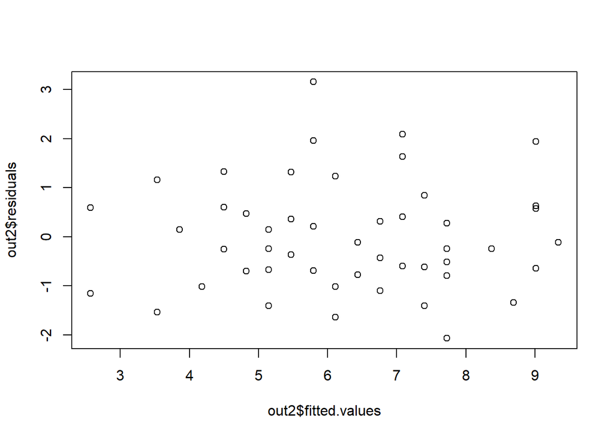

```r
plot(out2$fitted.values, out2$residuals) #잔차도표를 그려서 시각적으로 확인
```

```r
durbinWatsonTest(out2)
```

```
##  lag Autocorrelation D-W Statistic p-value
##    1      0.01762836      1.941736   0.716
##  Alternative hypothesis: rho != 0
```

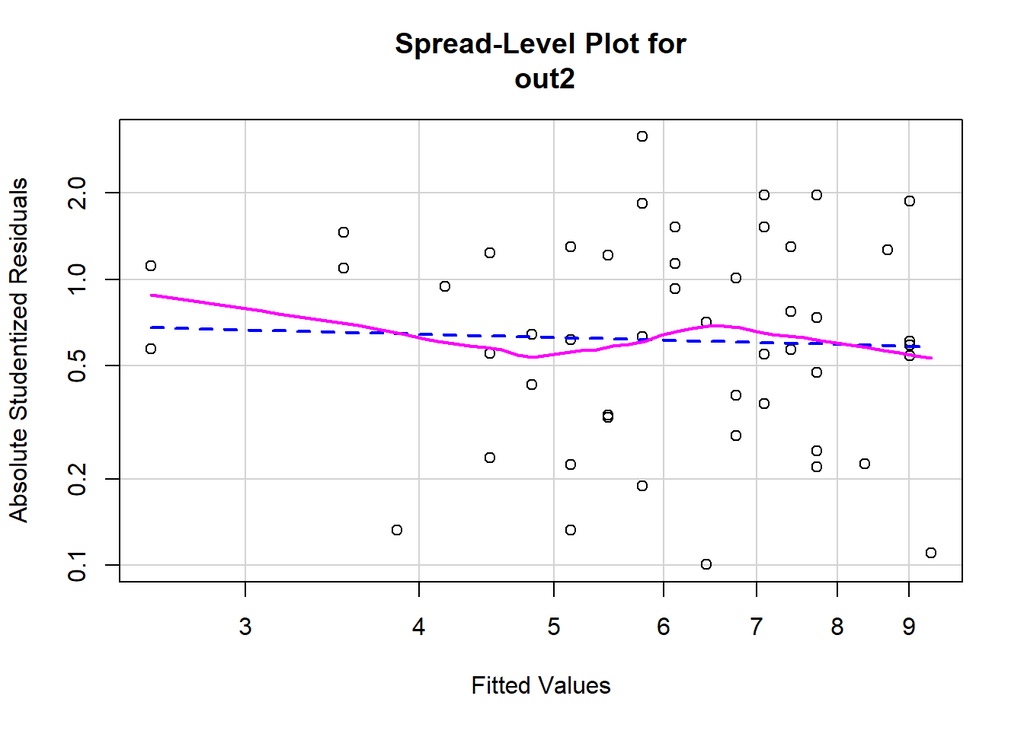

```
##
## Suggested power transformation:  1.118288
```

```r
spreadLevelPlot(out2)
```

```r
ncvTest(out2) # 등분산성을 만족
```

```
## Non-constant Variance Score Test
## Variance formula: ~ fitted.values
## Chisquare = 0.01205185, Df = 1, p = 0.91258
```

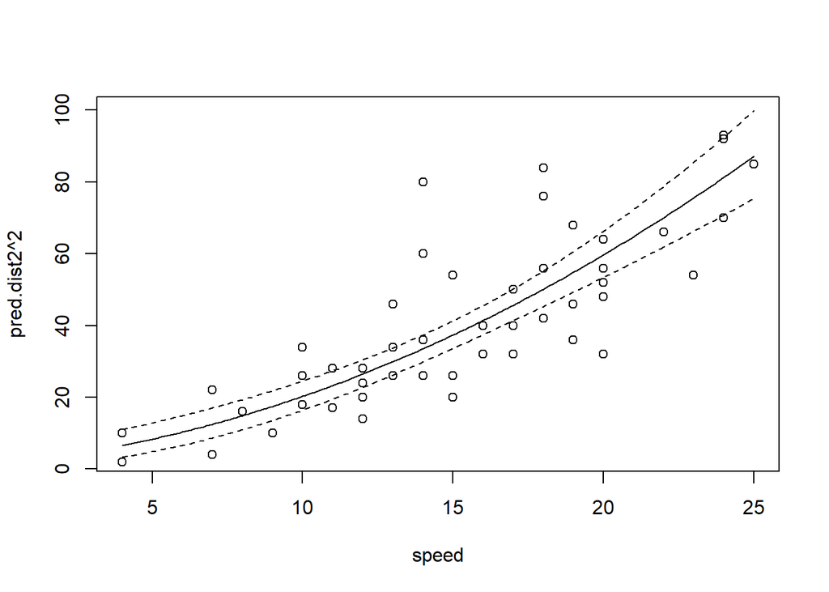

```r
# 단순회귀모형의 시각화
speed <- seq(min(cars$speed), max(cars$speed),.1)
pred.dist2 <- predict(out2, newdata=data.frame(speed=speed), interval="confidence")
matplot(speed, pred.dist2^2, type='n')
matlines(speed, pred.dist2^2, lty=c(1,2,2), col=1) # 선형 회귀식은 직선, 신뢰구간은 점선으로 표현
matpoints(cars$speed, cars$dist, pch=1)
```

### Example

```r
alligator = data.frame(
  lnLength = c(3.87, 3.61, 4.33, 3.43, 3.81, 3.83, 3.46, 3.76,
               3.50, 3.58, 4.19, 3.78, 3.71, 3.73, 3.78),
  lnWeight = c(4.87, 3.93, 6.46, 3.33, 4.38, 4.70, 3.50, 4.50,
               3.58, 3.64, 5.90, 4.43, 4.38, 4.42, 4.25)
)
```

- 악어자료의 정규성, 독립성, 등분산성을 확인하세요.

## 가정문제 해결

### 책의 부피와 무게에 대한 회귀모형

```r
volume = c(412,953,929,1492,419,1010,595,1034)
weight = c(250,700,650,975,350,950,425,725)

data <- data.frame(volume, weight)
out <- lm(weight~volume, data=data)
confint(out) # 95% confidence interval for regression coefficient
```

```
##                    2.5 %      97.5 %
## (Intercept) -197.3453843 280.0903358
## volume         0.4266644   0.9450539
```

### ggplot2를 이용한 시각화

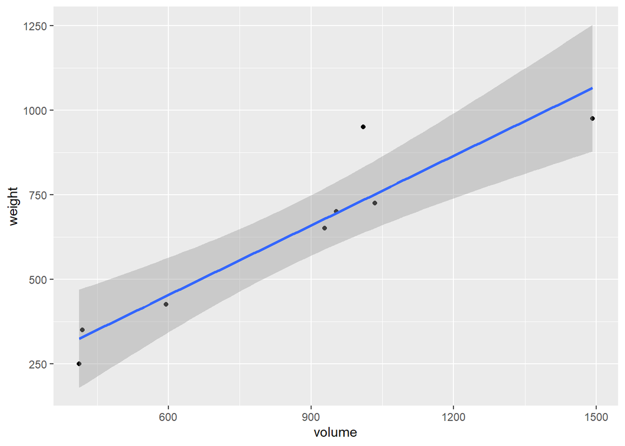

```r
library(ggplot2)
ggplot(data=data, aes(x=volume, y=weight))+geom_point()+stat_smooth( method="lm")
```

- 오류가 발생할 경우 ggplot2 패키지를 설치하세요.
- 이제 정규성을 확인하겠습니다.

```r
library(car)
shapiro.test(out$residuals)# 정규성을 만족하지 않음
```

```
##
##  Shapiro-Wilk normality test
##
## data:  out$residuals
## W = 0.77895, p-value = 0.01697
```

- Box-Cox transformation은 종속변수를 변환하여 최대한 좌우대칭이 되도록 만들어 줍니다.

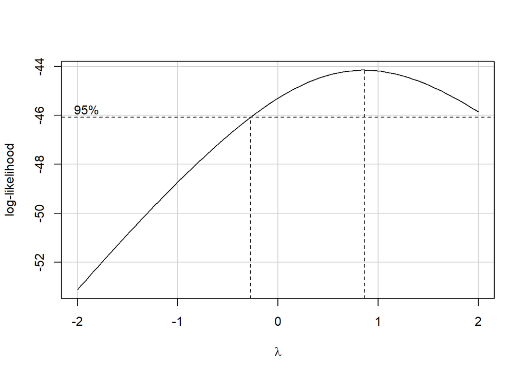

```r
# 해결방법 1 (boxcox transformation)
boxCox(weight~volume)
```

```r
box1 <-boxCox(weight~volume, lambda=seq(0.5,1.3,0.05)) # detail
```

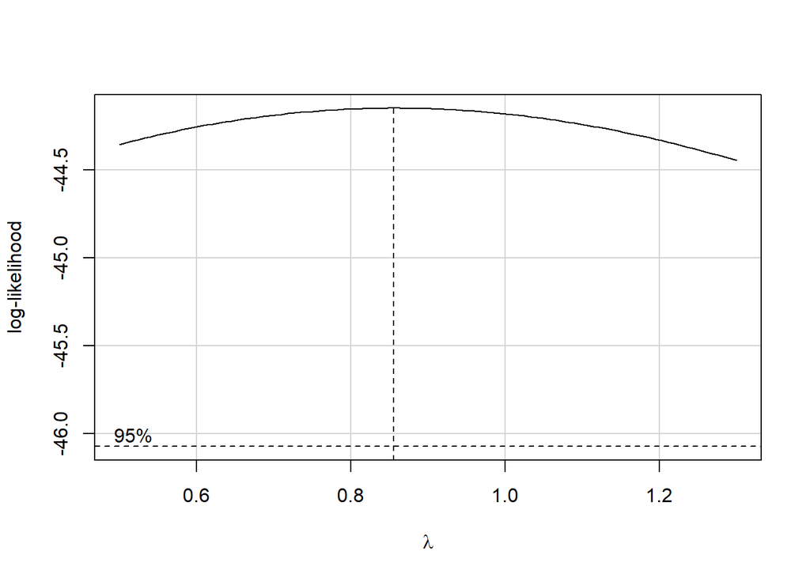

```r
box1
```

```
## $x
##   [1] 0.5000000 0.5080808 0.5161616 0.5242424 0.5323232 0.5404040 0.5484848
##   [8] 0.5565657 0.5646465 0.5727273 0.5808081 0.5888889 0.5969697 0.6050505
##  [15] 0.6131313 0.6212121 0.6292929 0.6373737 0.6454545 0.6535354 0.6616162
##  [22] 0.6696970 0.6777778 0.6858586 0.6939394 0.7020202 0.7101010 0.7181818
##  [29] 0.7262626 0.7343434 0.7424242 0.7505051 0.7585859 0.7666667 0.7747475
##  [36] 0.7828283 0.7909091 0.7989899 0.8070707 0.8151515 0.8232323 0.8313131
##  [43] 0.8393939 0.8474747 0.8555556 0.8636364 0.8717172 0.8797980 0.8878788
##  [50] 0.8959596 0.9040404 0.9121212 0.9202020 0.9282828 0.9363636 0.9444444
##  [57] 0.9525253 0.9606061 0.9686869 0.9767677 0.9848485 0.9929293 1.0010101
##  [64] 1.0090909 1.0171717 1.0252525 1.0333333 1.0414141 1.0494949 1.0575758
##  [71] 1.0656566 1.0737374 1.0818182 1.0898990 1.0979798 1.1060606 1.1141414
##  [78] 1.1222222 1.1303030 1.1383838 1.1464646 1.1545455 1.1626263 1.1707071
##  [85] 1.1787879 1.1868687 1.1949495 1.2030303 1.2111111 1.2191919 1.2272727
##  [92] 1.2353535 1.2434343 1.2515152 1.2595960 1.2676768 1.2757576 1.2838384
```

[output cut: 18 more lines]

```r
box1$x[which(box1$y==max(box1$y))] #최대가 되는 lambda값 선택
```

```
## [1] 0.8555556
```

```r
out1 <- lm(weight^0.86~volume) # 최대가 되는 lambda값을 종속변수의 파워로 넣어줌
shapiro.test(out1$residuals)
```

```
##
##  Shapiro-Wilk normality test
##
## data:  out1$residuals
## W = 0.80856, p-value = 0.03532
```

- 기존 방법에 비해 정규성이 가까워지만 해결되지 않음.
- 이 경우 분위수 회귀모형으로 선형모형 추정

```r
# 분위수 회귀모형: quantreg 패키지 필요
if(!require(quantreg)) install.packages("quantreg")
library(quantreg)

out2 <- rq(weight~volume, 0.5 )
summary(out2)
```

```
##
## Call: rq(formula = weight ~ volume, tau = 0.5)
##
## tau: [1] 0.5
##
## Coefficients:
##             coefficients lower bd  upper bd
## (Intercept) 103.52941    -67.00539 159.93155
## volume        0.58824      0.57846   0.82608
```

```r
mean(out2$residuals) # 평균이 0이 아님
```

```
## [1] 21.36029
```

```r
# 정규분포를 가정하지 않은 모형이므로 정규분포에 대한 가설검정 불 필요
```

### 오차들간 자기상관성이 있는 경우?

```r
data <- read.csv("C:/Users/stats/Documents/R 중급강좌 (통계교육원)/Day2/example.csv")
head(data)
```

```
##         DATE LRHUTTTTUSM156S
## 1 1960-01-01             5.2
## 2 1960-02-01             4.8
## 3 1960-03-01             5.4
## 4 1960-04-01             5.2
## 5 1960-05-01             5.1
## 6 1960-06-01             5.4
```

```r
tail(data)
```

```
##           DATE LRHUTTTTUSM156S
## 722 2020-02-01             3.5
## 723 2020-03-01             4.4
## 724 2020-04-01            14.7
## 725 2020-05-01            13.3
## 726 2020-06-01            11.1
## 727 2020-07-01            10.2
```

```r
data$x=1:727
names(data)=c("month", "y", "x")
head(data)
```

```
##        month   y x
## 1 1960-01-01 5.2 1
## 2 1960-02-01 4.8 2
## 3 1960-03-01 5.4 3
## 4 1960-04-01 5.2 4
## 5 1960-05-01 5.1 5
## 6 1960-06-01 5.4 6
```

- 인터넷에서 자료를 다운 받아 활용하겠습니다.
- x와 y의 관계를 시각화 하고 선형모형을 세우면 아래와 같습니다.

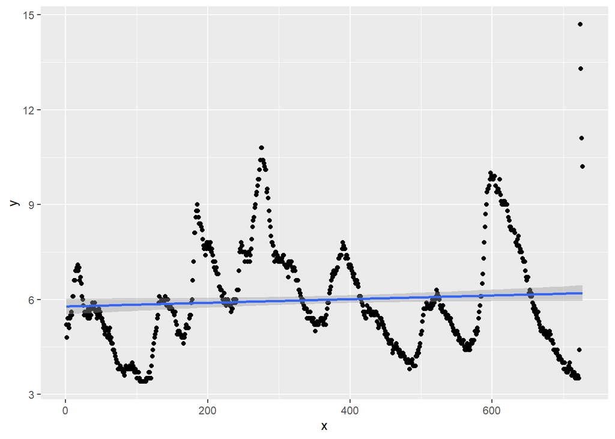

```r
ggplot(data=data, aes(x=x, y=y))+geom_point()+stat_smooth( method="lm")
```

```r
out <- lm(y~x, data=data)
summary(out)
```

```
##
## Call:
## lm(formula = y ~ x, data = data)
##
## Residuals:
##     Min      1Q  Median      3Q     Max
## -2.6989 -1.1866 -0.2859  1.0975  8.5000
##
## Coefficients:
##              Estimate Std. Error t value Pr(>|t|)
## (Intercept) 5.7805995  0.1245276  46.420   <2e-16 ***
## x           0.0005793  0.0002964   1.955    0.051 .
## ---
## Signif. codes:  0 '***' 0.001 '**' 0.01 '*' 0.05 '.' 0.1 ' ' 1
##
## Residual standard error: 1.677 on 725 degrees of freedom
## Multiple R-squared:  0.005242,   Adjusted R-squared:  0.00387
## F-statistic: 3.821 on 1 and 725 DF,  p-value: 0.05101
```

```r
shapiro.test(out$residuals)
```

```
##
##  Shapiro-Wilk normality test
##
## data:  out$residuals
## W = 0.95069, p-value = 7.3e-15
```

```r
set.seed(124312)
durbinWatsonTest(out) # 자기 상관성을 만족하지 않음.
```

```
##  lag Autocorrelation D-W Statistic p-value
##    1       0.9623915    0.06721186       0
##  Alternative hypothesis: rho != 0
```

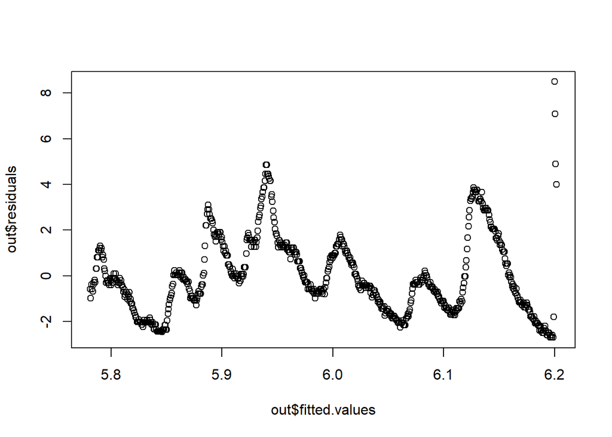

```r
plot(out$fitted.values, out$residuals)
```

- acf와 pacf 함수를 통해 자기 상관성 확인(자세한 내용은 : 시계열 분석)

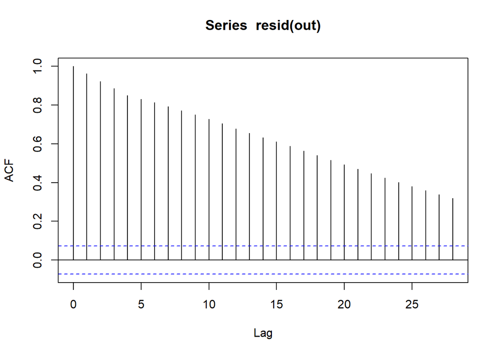

```r
acf(resid(out))
```

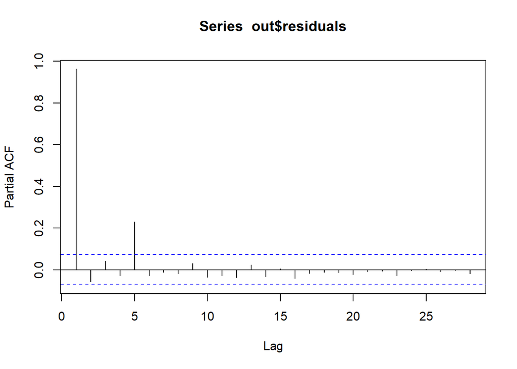

```r
pacf(out$residuals)
```

- 해결방법: nlme 패키지의 gls 함수로 해결 가능

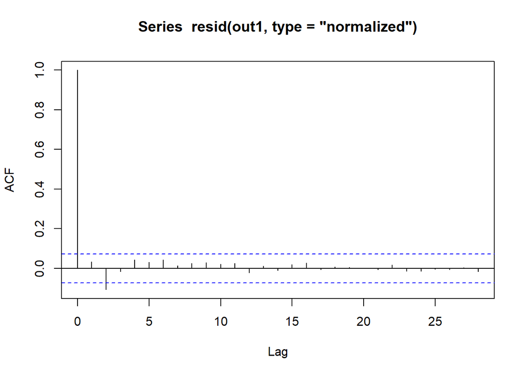

```r
if(!require(nlme)) install.packages("nlme")
library(nlme)

out1 <- gls(y~x, data=data, correlation = corAR1(form=~x), method="ML")
acf(resid(out1, type="normalized"))
```

```r
logLik(out)
```

```
## 'log Lik.' -1406.467 (df=3)
```

```r
logLik(out1)
```

```
## 'log Lik.' -421.4073 (df=4)
```

```r
summary(out)
```

```
##
## Call:
## lm(formula = y ~ x, data = data)
##
## Residuals:
##     Min      1Q  Median      3Q     Max
## -2.6989 -1.1866 -0.2859  1.0975  8.5000
##
## Coefficients:
##              Estimate Std. Error t value Pr(>|t|)
## (Intercept) 5.7805995  0.1245276  46.420   <2e-16 ***
## x           0.0005793  0.0002964   1.955    0.051 .
## ---
## Signif. codes:  0 '***' 0.001 '**' 0.01 '*' 0.05 '.' 0.1 ' ' 1
##
## Residual standard error: 1.677 on 725 degrees of freedom
## Multiple R-squared:  0.005242,   Adjusted R-squared:  0.00387
## F-statistic: 3.821 on 1 and 725 DF,  p-value: 0.05101
```

```r
summary(out1)
```

```
## Generalized least squares fit by maximum likelihood
##   Model: y ~ x
##   Data: data
##        AIC      BIC    logLik
##   850.8147 869.1704 -421.4073
##
## Correlation Structure: AR(1)
##  Formula: ~x
##  Parameter estimate(s):
##       Phi
## 0.9687019
##
## Coefficients:
##                Value Std.Error  t-value p-value
## (Intercept) 5.416395 0.9262322 5.847772  0.0000
## x           0.001948 0.0021573 0.903049  0.3668
##
##  Correlation:
##   (Intr)
## x -0.848
##
## Standardized residuals:
##        Min         Q1        Med         Q3        Max
## -1.9129615 -0.8671999 -0.2045830  0.5991095  4.5323704
##
## Residual standard error: 1.737087
## Degrees of freedom: 727 total; 725 residual
```

> 오차항의 자기상관성이 제거된 선형식으로 추정됨

> 시계열모형과 같이 x가 제거된 식으로 모형화가 필요
- lag data를 이용하여 ar(1) 모형으로 적합

### 등분산성을 만족하지 않는다면

```r
load(file="C:/Users/stats/Documents/R 중급강좌 (통계교육원)/Day2/hospital1.rdata")
head(hospital1)
```

```
##        admit gender marital katz1 katz2 katz3 katz4 katz5 katz6 iad1 iad2 iad3
## 1 1993-02-05   Male Married     3     3     3     3     3     3    3    3    3
## 2 1993-02-05 Female Widowed     3     3     3     3     2     3    3    1    3
## 3 1993-02-05 Female Widowed     3     3     3     3     3     3    3    3    3
## 4 1993-02-06   Male Married     3     3     3     3     3     3    3    3    3
## 5 1993-02-03 Female Married     3     3     3     3     3     3    3    3    3
## 6 1993-02-03   Male Married     1     2     2     2     1     3    3    2    2
##   iad4 iad5 iad6 iad7    disdate return30      age spouse      agecat age80
## 1    3    3    3    3 1993-02-20       no 80.25479     no 80 or older     1
## 2    3    3    3    3 1993-02-12       no 83.55068     no 80 or older     1
## 3    3    3    3    3 1993-02-11       no 79.02192     no       75-79     0
## 4    2    3    3    3 1993-02-13       no 76.13151    yes       75-79     0
## 5    3    3    3    3 1993-02-11       no 66.62192     no       65-69     0
## 6    1    1    2    1 1993-02-09       no 76.22192    yes       75-79     0
##   tkatzsum tkatzmean tiadlmean los
## 1       18      3.00  3.000000  15
## 2       17      2.75  2.714286   7
## 3       18      3.00  3.000000   6
## 4       18      3.00  2.857143   7
## 5       18      3.00  3.000000   8
## 6       11      1.75  1.714286   6
```

```r
out <- lm(los~tkatzmean, data=hospital1)
summary(out)
```

```
##
## Call:
## lm(formula = los ~ tkatzmean, data = hospital1)
##
## Residuals:
##     Min      1Q  Median      3Q     Max
## -32.529  -7.400  -3.902   5.347  66.600
##
## Coefficients:
##             Estimate Std. Error t value Pr(>|t|)
## (Intercept)   57.906      5.291   10.94  < 2e-16 ***
## tkatzmean    -15.502      1.967   -7.88 4.86e-13 ***
## ---
## Signif. codes:  0 '***' 0.001 '**' 0.01 '*' 0.05 '.' 0.1 ' ' 1
##
## Residual standard error: 15.05 on 159 degrees of freedom
## Multiple R-squared:  0.2809, Adjusted R-squared:  0.2763
## F-statistic: 62.09 on 1 and 159 DF,  p-value: 4.861e-13
```

```r
shapiro.test(out$residuals)
```

```
##
##  Shapiro-Wilk normality test
##
## data:  out$residuals
## W = 0.84779, p-value = 1.209e-11
```

```r
durbinWatsonTest(out)
```

```
##  lag Autocorrelation D-W Statistic p-value
##    1      0.04157322      1.916334    0.54
##  Alternative hypothesis: rho != 0
```

```r
ncvTest(out)
```

```
## Non-constant Variance Score Test
## Variance formula: ~ fitted.values
## Chisquare = 44.77061, Df = 1, p = 2.2152e-11
```

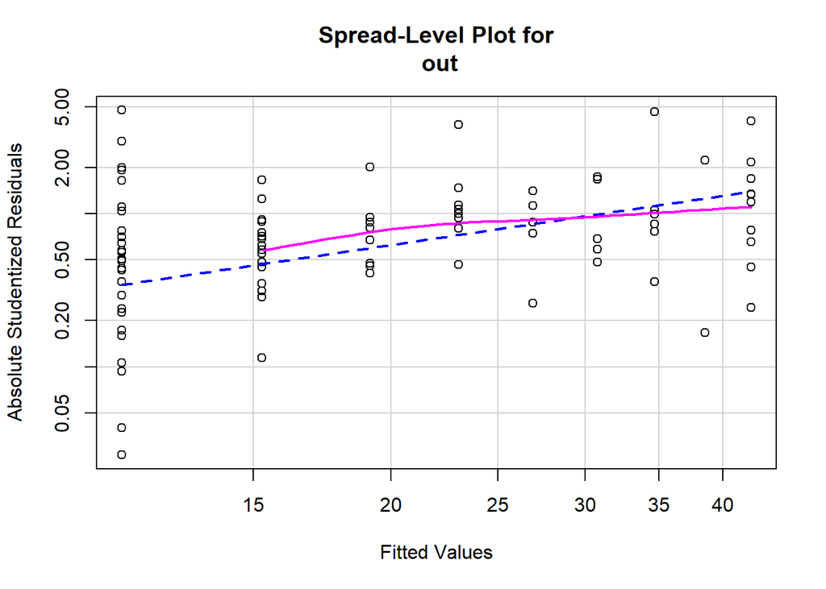

```
##
## Suggested power transformation:  -0.0633793
```

```r
spreadLevelPlot(out)
```

- spreadLevelPlot에서 제안해주는 power를 y에 넣어 보자.

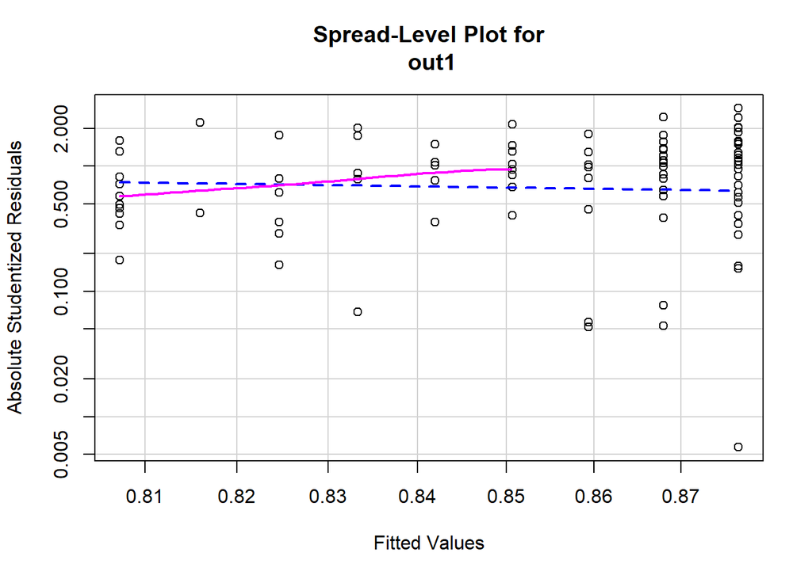

```
##
## Suggested power transformation:  2.908408
```

```r
# 이분산성 해결
out1 <- lm(los^-0.06~tkatzmean, data=hospital1)
spreadLevelPlot(out1)
```

```r
ncvTest(out1)
```

```
## Non-constant Variance Score Test
## Variance formula: ~ fitted.values
## Chisquare = 0.1235061, Df = 1, p = 0.72526
```

```r
durbinWatsonTest(out1)
```

```
##  lag Autocorrelation D-W Statistic p-value
##    1      0.07372261      1.849438   0.326
##  Alternative hypothesis: rho != 0
```

```r
shapiro.test(out1$residuals)
```

```
##
##  Shapiro-Wilk normality test
##
## data:  out1$residuals
## W = 0.99088, p-value = 0.392
```

```r
summary(out1)
```

```
##
## Call:
## lm(formula = los^-0.06 ~ tkatzmean, data = hospital1)
##
## Residuals:
##      Min       1Q   Median       3Q      Max
## -0.10673 -0.02667  0.00600  0.02899  0.09124
##
## Coefficients:
##             Estimate Std. Error t value Pr(>|t|)
## (Intercept) 0.772512   0.013323  57.984  < 2e-16 ***
## tkatzmean   0.034730   0.004954   7.011 6.38e-11 ***
## ---
## Signif. codes:  0 '***' 0.001 '**' 0.01 '*' 0.05 '.' 0.1 ' ' 1
##
## Residual standard error: 0.03789 on 159 degrees of freedom
## Multiple R-squared:  0.2362, Adjusted R-squared:  0.2313
## F-statistic: 49.16 on 1 and 159 DF,  p-value: 6.378e-11
```

- 주의, 선형식의 y값은 변환된 값이므로 예측할 때 주의가 필요함
- 또다른 예제

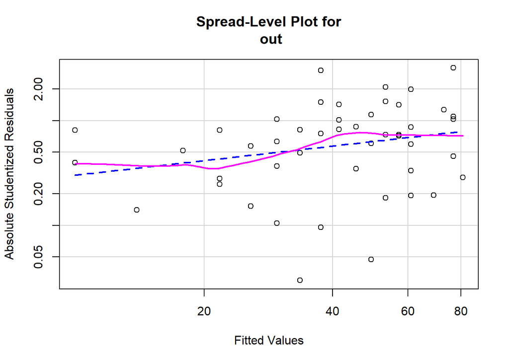

```
##
## Suggested power transformation:  0.5402974
```

```r
out<- lm(dist~speed, cars)
spreadLevelPlot(out)
```

```r
ncvTest(out)
```

```
## Non-constant Variance Score Test
## Variance formula: ~ fitted.values
## Chisquare = 4.650233, Df = 1, p = 0.031049
```

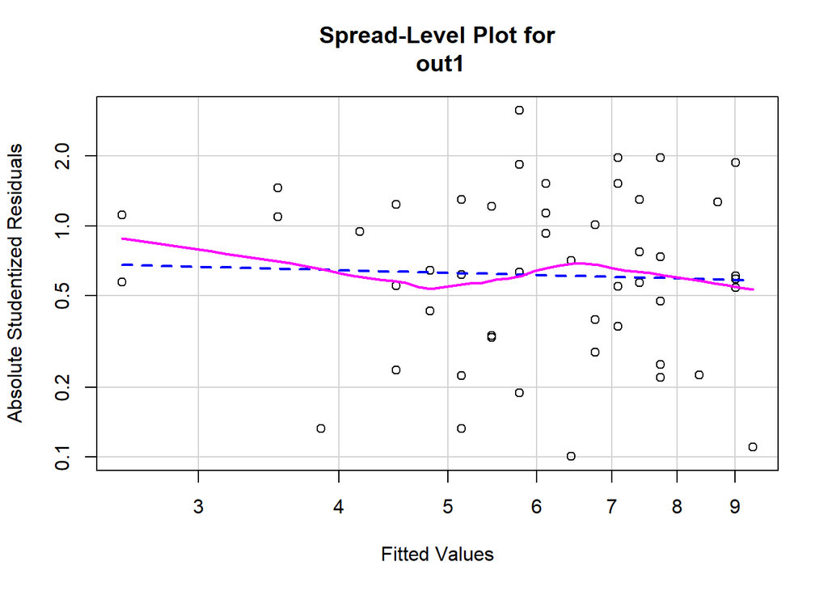

```
##
## Suggested power transformation:  1.118288
```

```r
out1<- lm(dist^0.5~speed, cars)
spreadLevelPlot(out1)
```

```r
ncvTest(out1)
```

```
## Non-constant Variance Score Test
## Variance formula: ~ fitted.values
## Chisquare = 0.01205185, Df = 1, p = 0.91258
```

- gls를 이용한 해결

```r
out.gls <- gls(dist~ speed, data=cars, weight = varConstPower(1, form=~speed))
summary(out.gls)
```

```
## Generalized least squares fit by REML
##   Model: dist ~ speed
##   Data: cars
##        AIC      BIC    logLik
##   412.8352 422.1912 -201.4176
##
## Variance function:
##  Structure: Constant plus power of variance covariate
##  Formula: ~speed
##  Parameter estimates:
##    const    power
## 3.160444 1.022368
##
## Coefficients:
##                  Value Std.Error   t-value p-value
## (Intercept) -11.085378  4.052378 -2.735524  0.0087
## speed         3.484162  0.320237 10.879947  0.0000
##
##  Correlation:
##       (Intr)
## speed -0.9
##
## Standardized residuals:
##        Min         Q1        Med         Q3        Max
## -1.4520579 -0.6898209 -0.1308277  0.6375029  3.0757014
##
## Residual standard error: 0.7636833
## Degrees of freedom: 50 total; 48 residual
```

로 speed에 따라 분산이 변하도록 모형을 재설계하고 그 변화된 분산에 따라 회귀계수를 재추정한 결과임.

```r
logLik(out)
```

```
## 'log Lik.' -206.5784 (df=3)
```

```r
logLik(out.gls)
```

```
## 'log Lik.' -201.4176 (df=5)
```